# Desafio Solarview

Semar Augusto

# Data loading

```r
states <- readOGR("UFEBRASIL.shp", encoding = "UTF-8")
df <- read.csv("radiacao_sql.csv", encoding = "UTF-8")
```

# Initial Description

```r
summary(df)
```

```
##       LON              LAT              YEAR           JAN
##  Min.   :-73.25   Min.   :-33.25   Min.   :1984   Min.   :2.940
##  1st Qu.:-59.25   1st Qu.:-16.25   1st Qu.:1989   1st Qu.:4.480
##  Median :-52.50   Median : -9.25   Median :1994   Median :4.910
##  Mean   :-53.05   Mean   :-10.70   Mean   :1994   Mean   :5.065
##  3rd Qu.:-46.75   3rd Qu.: -4.75   3rd Qu.:2000   3rd Qu.:5.630
##  Max.   :-35.25   Max.   :  5.25   Max.   :2005   Max.   :8.360
##
##       FEB             MAR             APR             MAY
##  Min.   :2.900   Min.   :3.270   Min.   :2.600   Min.   :2.210
##  1st Qu.:4.490   1st Qu.:4.410   1st Qu.:4.360   1st Qu.:4.100
##  Median :4.930   Median :4.780   Median :4.680   Median :4.480
##  Mean   :5.049   Mean   :4.835   Mean   :4.704   Mean   :4.468
##  3rd Qu.:5.560   3rd Qu.:5.210   3rd Qu.:5.050   3rd Qu.:4.900
##  Max.   :7.550   Max.   :7.270   Max.   :6.410   Max.   :6.210
##
##       JUN            JUL             AUG             SEP
##  Min.   :1.61   Min.   :2.010   Min.   :2.440   Min.   :2.550
##  1st Qu.:4.07   1st Qu.:4.420   1st Qu.:4.890   1st Qu.:5.040
##  Median :4.61   Median :4.990   Median :5.340   Median :5.400
##  Mean   :4.53   Mean   :4.863   Mean   :5.263   Mean   :5.414
##  3rd Qu.:5.10   3rd Qu.:5.430   3rd Qu.:5.730   3rd Qu.:5.820
##  Max.   :6.10   Max.   :6.360   Max.   :6.900   Max.   :7.390
##
##       OCT            NOV             DEC             ANN
##  Min.   :2.75   Min.   :3.320   Min.   :2.950   Min.   :3.76
##  1st Qu.:5.07   1st Qu.:4.800   1st Qu.:4.530   1st Qu.:4.73
##  Median :5.42   Median :5.180   Median :4.960   Median :4.97
##  Mean   :5.46   Mean   :5.285   Mean   :5.071   Mean   :5.00
##  3rd Qu.:5.83   3rd Qu.:5.723   3rd Qu.:5.520   3rd Qu.:5.24
##  Max.   :7.55   Max.   :7.860   Max.   :7.910   Max.   :6.29
##
##                 STATE
##  AMAZONAS          :13838
##  PARÁ              :11044
##  MATO GROSSO       : 8272
##  MINAS GERAIS      : 5654
##  BAHIA             : 4862
##  MATO GROSSO DO SUL: 3322
##  (Other)           :30052
```

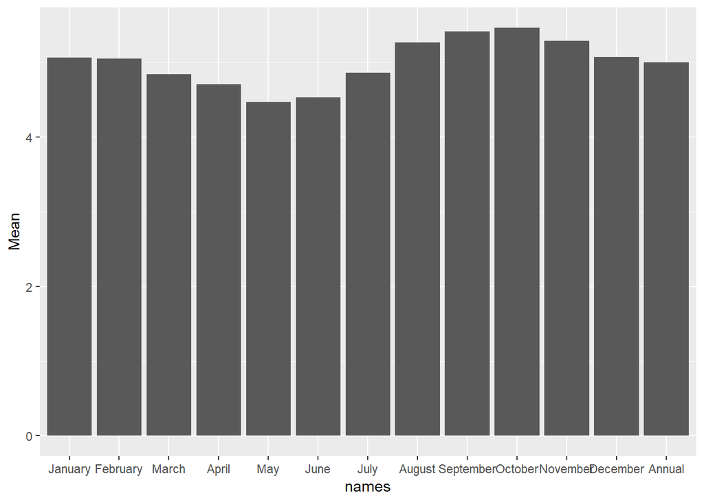

```r
means <- as.data.frame((apply(df[,4:16], 2, mean)))
colnames(means) <- "Mean"
means$names <- factor(c(month.name, "Annual"), levels=c(month.name, "Annual"))
ggplot(means, aes(x = names, y = Mean)) + geom_bar(stat='identity')
```

I would expect that there would be a big difference in the mean and median whilst comparing winter and summer time. It seems not to be the case. However, Brazil is a big country and has a big part of its land area in the Equador. Let’s check if in a smaller region further away from Equador will express this difference.

```r
sc <- subset(df, STATE == "SANTA CATARINA")
summary(sc)
```

```
##       LON              LAT              YEAR           JAN
##  Min.   :-53.25   Min.   :-29.25   Min.   :1984   Min.   :4.14
##  1st Qu.:-51.25   1st Qu.:-27.75   1st Qu.:1989   1st Qu.:5.20
##  Median :-50.25   Median :-27.25   Median :1994   Median :5.64
##  Mean   :-50.38   Mean   :-27.35   Mean   :1994   Mean   :5.65
##  3rd Qu.:-49.25   3rd Qu.:-26.75   3rd Qu.:2000   3rd Qu.:6.04
##  Max.   :-48.75   Max.   :-26.25   Max.   :2005   Max.   :7.29
##
##       FEB             MAR             APR             MAY
##  Min.   :3.700   Min.   :3.610   Min.   :2.800   Min.   :2.280
##  1st Qu.:4.690   1st Qu.:4.300   1st Qu.:3.422   1st Qu.:2.890
##  Median :5.160   Median :4.680   Median :3.655   Median :3.200
##  Mean   :5.170   Mean   :4.685   Mean   :3.753   Mean   :3.151
##  3rd Qu.:5.588   3rd Qu.:5.040   3rd Qu.:4.060   3rd Qu.:3.420
##  Max.   :6.750   Max.   :6.120   Max.   :4.960   Max.   :4.130
##
##       JUN             JUL             AUG             SEP
##  Min.   :2.000   Min.   :2.370   Min.   :2.440   Min.   :2.550
##  1st Qu.:2.600   1st Qu.:2.830   1st Qu.:3.422   1st Qu.:3.660
##  Median :2.740   Median :3.040   Median :3.805   Median :3.990
##  Mean   :2.751   Mean   :3.053   Mean   :3.738   Mean   :4.008
##  3rd Qu.:2.890   3rd Qu.:3.280   3rd Qu.:4.070   3rd Qu.:4.420
##  Max.   :3.460   Max.   :3.880   Max.   :4.740   Max.   :5.190
##
##       OCT             NOV             DEC             ANN
##  Min.   :2.750   Min.   :3.780   Min.   :4.150   Min.   :3.780
##  1st Qu.:4.242   1st Qu.:5.213   1st Qu.:5.510   1st Qu.:4.130
##  Median :4.800   Median :5.795   Median :5.850   Median :4.340
##  Mean   :4.762   Mean   :5.744   Mean   :5.871   Mean   :4.359
##  3rd Qu.:5.280   3rd Qu.:6.300   3rd Qu.:6.260   3rd Qu.:4.560
##  Max.   :6.190   Max.   :7.270   Max.   :7.010   Max.   :5.110
##
##             STATE
##  SANTA CATARINA:902
##  ACRE          :  0
##  ALAGOAS       :  0
##  AMAPÁ         :  0
##  AMAZONAS      :  0
##  BAHIA         :  0
##  (Other)       :  0
```

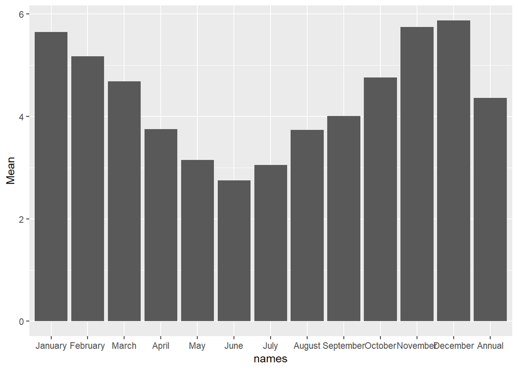

```r
means <- as.data.frame((apply(sc[,4:16], 2, mean)))
colnames(means) <- "Mean"
means$names <- factor(c(month.name, "Annual"), levels=c(month.name, "Annual"))
ggplot(means, aes(x = names, y = Mean)) + geom_bar(stat='identity')
```

```r
rm(sc)
```

As expected, a region further away from the Equador has bigger differences between summer and winter.

We’ll check now if by taking a a state closer to Equador will have simillar difference. That would mean that the fact that there is little difference overall in Brazil is due to a sum of variabilities

```r
am <- subset(df, STATE == "AMAZONAS")
summary(am)
```

```
##       LON              LAT              YEAR           JAN
##  Min.   :-73.25   Min.   :-9.750   Min.   :1984   Min.   :3.290
##  1st Qu.:-67.75   1st Qu.:-6.750   1st Qu.:1989   1st Qu.:4.240
##  Median :-64.75   Median :-4.250   Median :1994   Median :4.500
##  Mean   :-64.62   Mean   :-4.218   Mean   :1994   Mean   :4.524
##  3rd Qu.:-61.25   3rd Qu.:-2.250   3rd Qu.:2000   3rd Qu.:4.820
##  Max.   :-56.75   Max.   : 1.750   Max.   :2005   Max.   :6.250
##
##       FEB             MAR            APR             MAY
##  Min.   :3.120   Min.   :3.54   Min.   :3.360   Min.   :3.380
##  1st Qu.:4.260   1st Qu.:4.26   1st Qu.:4.230   1st Qu.:4.030
##  Median :4.480   Median :4.47   Median :4.400   Median :4.200
##  Mean   :4.499   Mean   :4.48   Mean   :4.403   Mean   :4.213
##  3rd Qu.:4.720   3rd Qu.:4.68   3rd Qu.:4.580   3rd Qu.:4.390
##  Max.   :6.040   Max.   :5.91   Max.   :5.500   Max.   :5.180
##
##       JUN             JUL             AUG             SEP
##  Min.   :3.130   Min.   :3.240   Min.   :3.810   Min.   :4.09
##  1st Qu.:4.010   1st Qu.:4.380   1st Qu.:4.850   1st Qu.:5.00
##  Median :4.240   Median :4.710   Median :5.100   Median :5.20
##  Mean   :4.295   Mean   :4.729   Mean   :5.093   Mean   :5.19
##  3rd Qu.:4.550   3rd Qu.:5.060   3rd Qu.:5.350   3rd Qu.:5.40
##  Max.   :5.670   Max.   :6.080   Max.   :6.020   Max.   :6.46
##
##       OCT             NOV             DEC             ANN
##  Min.   :3.860   Min.   :3.810   Min.   :3.250   Min.   :4.120
##  1st Qu.:4.880   1st Qu.:4.580   1st Qu.:4.300   1st Qu.:4.550
##  Median :5.120   Median :4.790   Median :4.520   Median :4.660
##  Mean   :5.106   Mean   :4.785   Mean   :4.534   Mean   :4.655
##  3rd Qu.:5.340   3rd Qu.:4.970   3rd Qu.:4.770   3rd Qu.:4.760
##  Max.   :6.280   Max.   :6.070   Max.   :5.790   Max.   :5.190
##
##       STATE
##  AMAZONAS:13838
##  ACRE    :    0
##  ALAGOAS :    0
##  AMAPÁ   :    0
##  BAHIA   :    0
##  CEARÁ   :    0
##  (Other) :    0
```

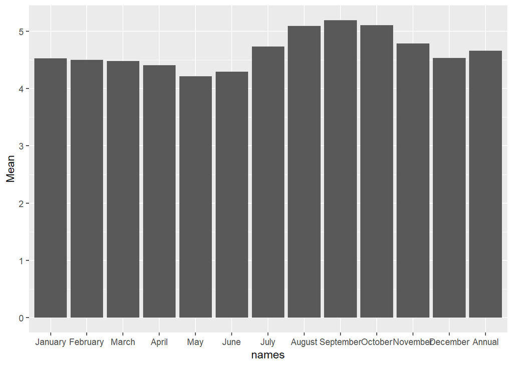

```r
means <- as.data.frame((apply(am[,4:16], 2, mean)))
colnames(means) <- "Mean"
means$names <- factor(c(month.name, "Annual"), levels=c(month.name, "Annual"))
ggplot(means, aes(x = names, y = Mean)) + geom_bar(stat='identity')
```

```r
rm(am)
```

As expected there is actually little variability in a state close to Equador.

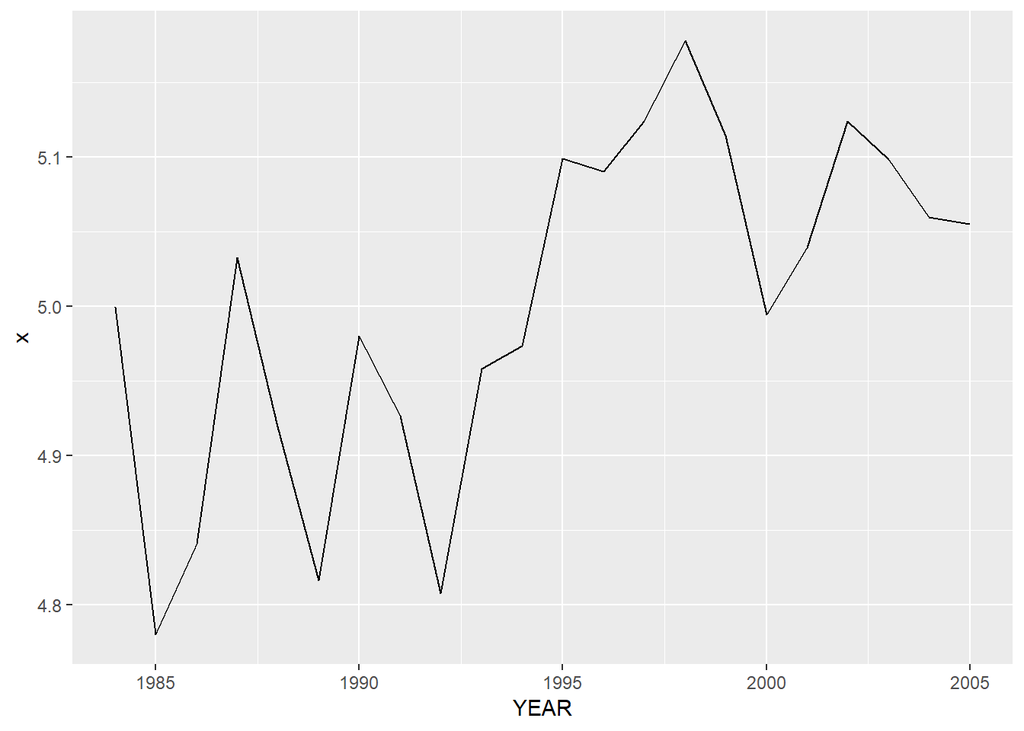

```r
df1 <- df
df1 <- aggregate(df1[,16], by=list(df1$YEAR), mean)
colnames(df1)[1] <- "YEAR"
ggplot(df1, aes(x=YEAR, y=x)) + geom_line()
```

Solar radiation seems to have pumped up by 1995 and hasn’t come down since.

# Time Series Analysis

I’ll transform the data frame in order to each month be a line. That will make it easier on the time series algorithms.

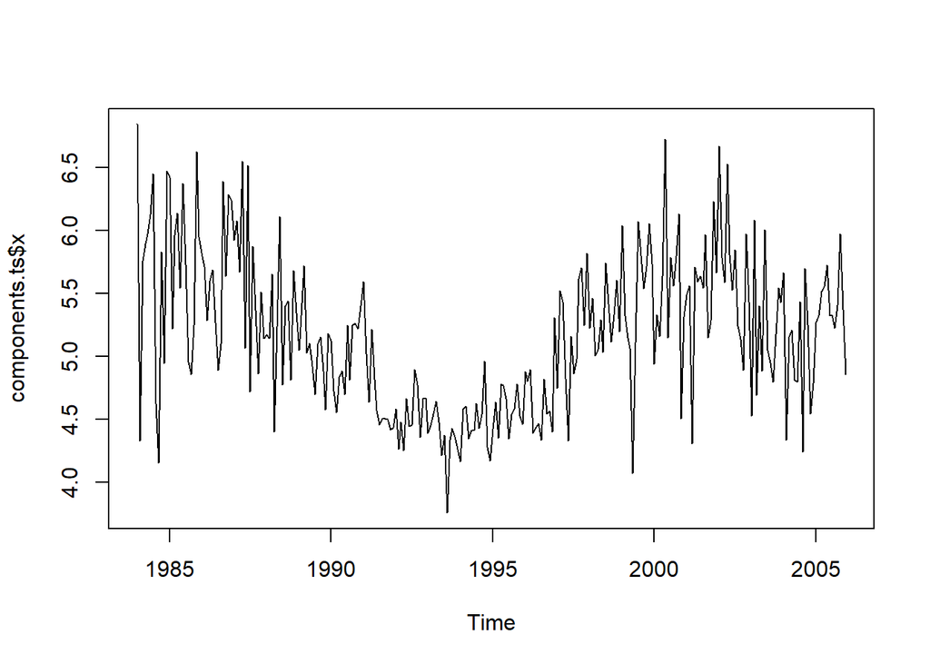

```r
df1 <- select(df, -"ANN")
df1 <- subset(df, STATE == "MINAS GERAIS")
df1 <- aggregate(df1[4:15], by=list(df1$YEAR, df1$STATE), mean)
colnames(df1)[1] <- "YEAR"
colnames(df1)[2] <- "STATE"
df1 <- melt(df1, id.vars=c("YEAR", "STATE"))

tsdf <- ts(df1[, c("value")])
tsdf <- ts(as.vector(tsdf), start = c(1984,1), frequency = 12)

components.ts <-  decompose(tsdf)
plot(components.ts$x)
```

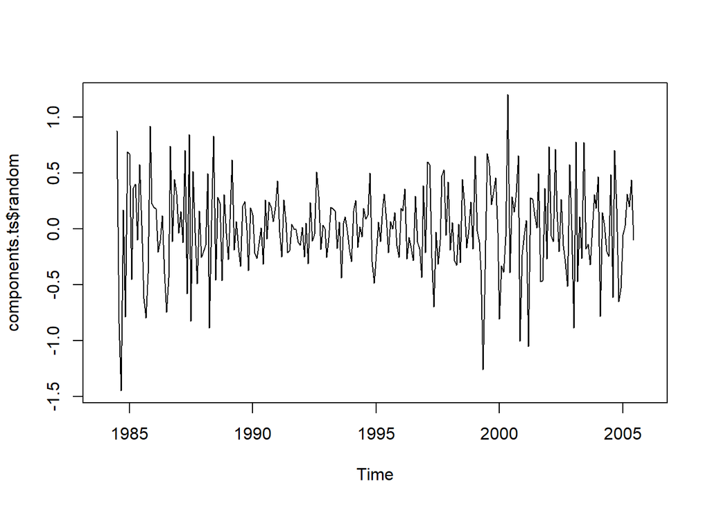

```r
plot(components.ts$random)
```

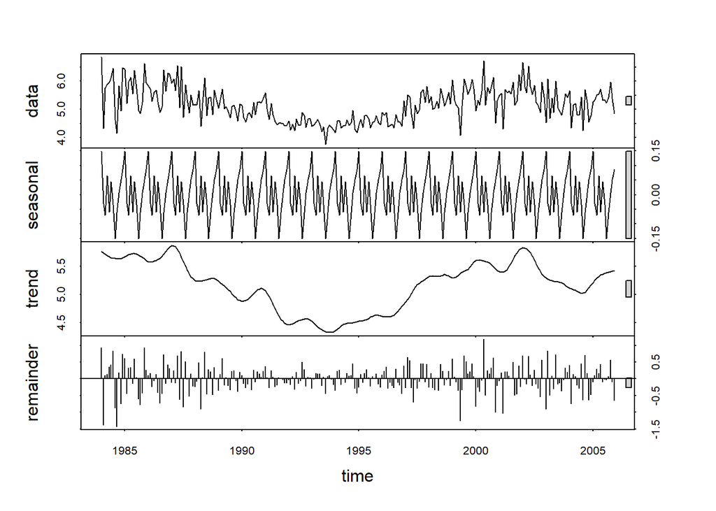

```r
decomp = stl(tsdf, s.window="periodic")
plot(decomp)
```

# Prediction

We’d like to predict what the next two years of radiation will be like. In order to do so, a ARIMA model is very common.

However, it requires stationary data. Let’s check if that is the case in our dataset.

```r
adf.test(tsdf, alternative = "stationary")
```

```
##
##  Augmented Dickey-Fuller Test
##
## data:  tsdf
## Dickey-Fuller = -2.5161, Lag order = 6, p-value = 0.3585
## alternative hypothesis: stationary
```

The formal ADF test does not reject null hypothesis, which means the dataset used is most likely a non-stationary one.

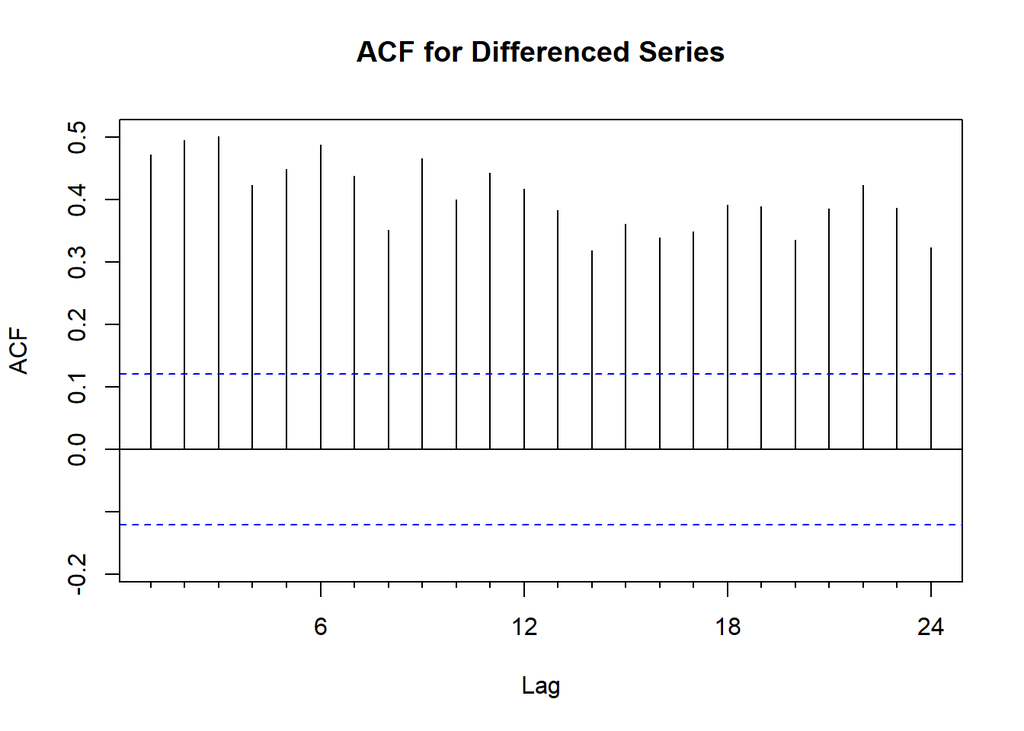

```r
Acf(tsdf, main='ACF for Differenced Series')
```

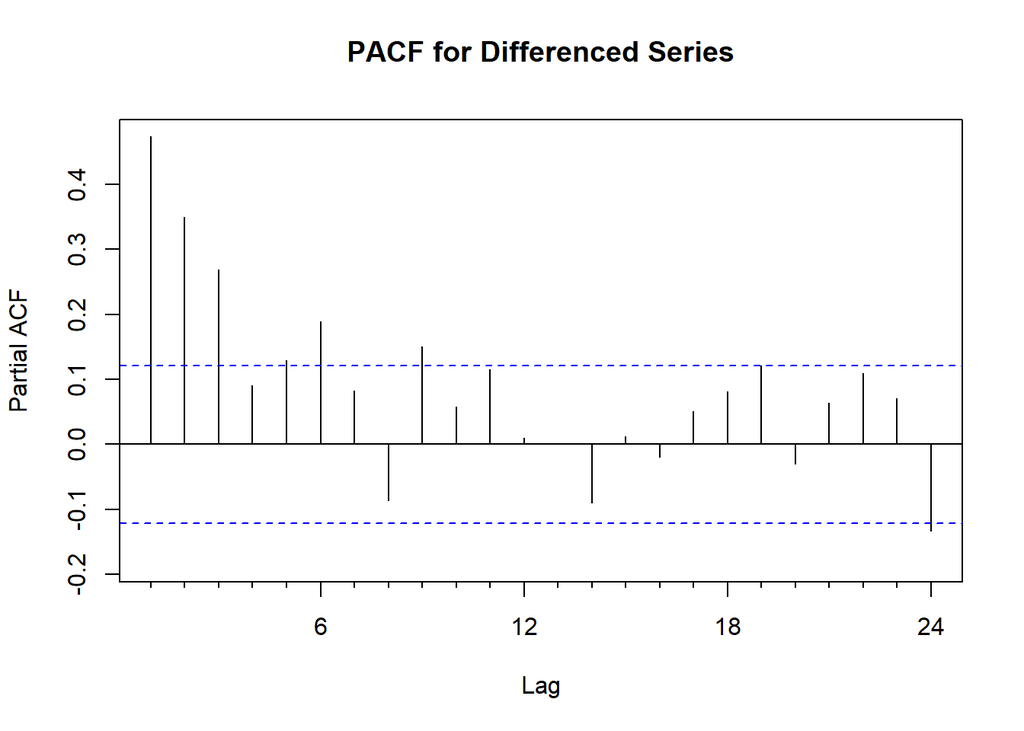

```r
Pacf(tsdf, main='PACF for Differenced Series')
```

We’ll use seasadj function to try to remove seasonality

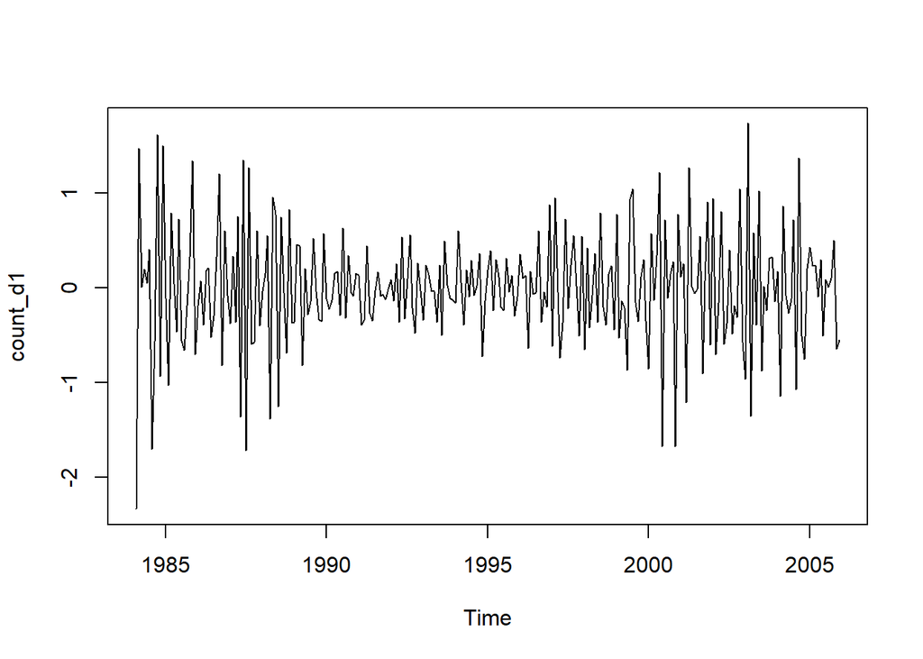

```r
deseasonal_cnt <- seasadj(decomp)
count_d1 = diff(deseasonal_cnt, differences = 1)
plot(count_d1)
```

```r
adf.test(count_d1, alternative = "stationary")
```

```
##
##  Augmented Dickey-Fuller Test
##
## data:  count_d1
## Dickey-Fuller = -8.4086, Lag order = 6, p-value = 0.01
## alternative hypothesis: stationary
```

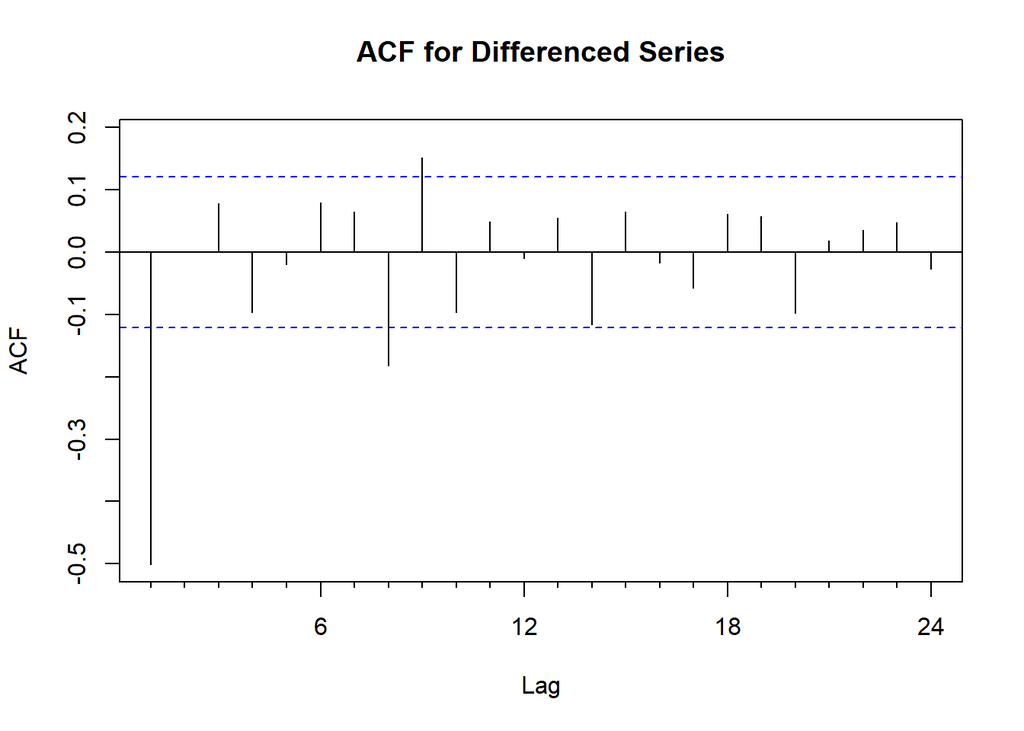

```r
Acf(count_d1, main='ACF for Differenced Series')
```

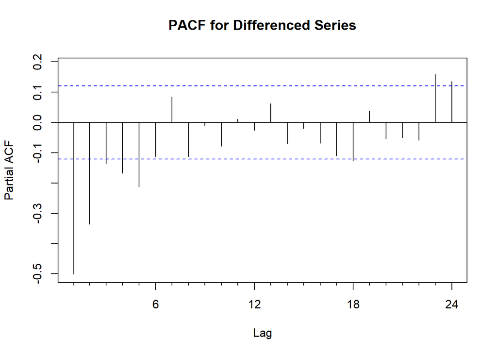

```r
Pacf(count_d1, main='PACF for Differenced Series')
```

Got our stationary dataset. Let’s proceed with the prediction process

# Predicting next two years

```r
fit_ts <- auto.arima(deseasonal_cnt, seasonal=FALSE)
fit_ts2 <- ets(tsdf)
fit_ts
```

```
## Series: deseasonal_cnt
## ARIMA(3,1,2)
##
## Coefficients:
##           ar1      ar2     ar3     ma1      ma2
##       -0.9733  -0.0016  0.0717  0.1195  -0.8151
## s.e.   0.0880   0.1227  0.0790  0.0613   0.0520
##
## sigma^2 estimated as 0.213:  log likelihood=-168.05
## AIC=348.11   AICc=348.43   BIC=369.54
```

```r
fit_ts2
```

```
## ETS(M,N,N)
##
## Call:
##  ets(y = tsdf)
##
##   Smoothing parameters:
##     alpha = 0.1655
##
##   Initial states:
##     l = 5.9275
##
##   sigma:  0.0874
##
##      AIC     AICc      BIC
## 1055.038 1055.130 1065.766
```

Arima model has better AIC, AICc and BIC, we’ll proceed with it.

[figure not shown]

```r
tsdisplay(residuals(fit_ts), lag.max=45, main='(1,1,1) Model Residuals')
```

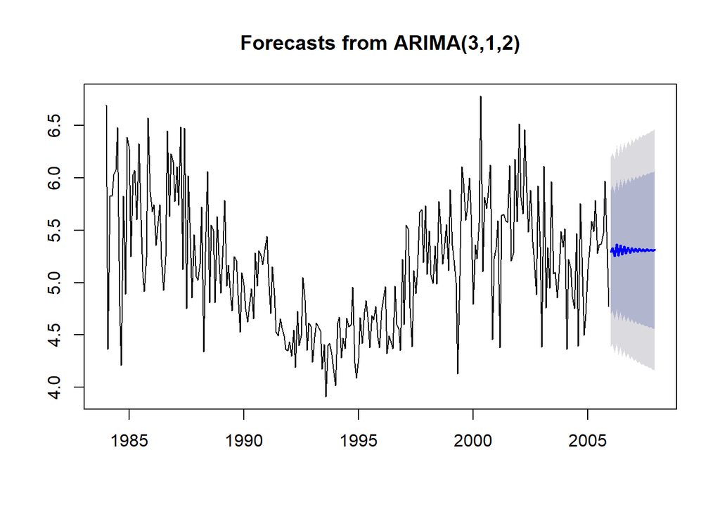

```r
fcast <- forecast(fit_ts, h=24)
plot(fcast)
```

# Spatial Description

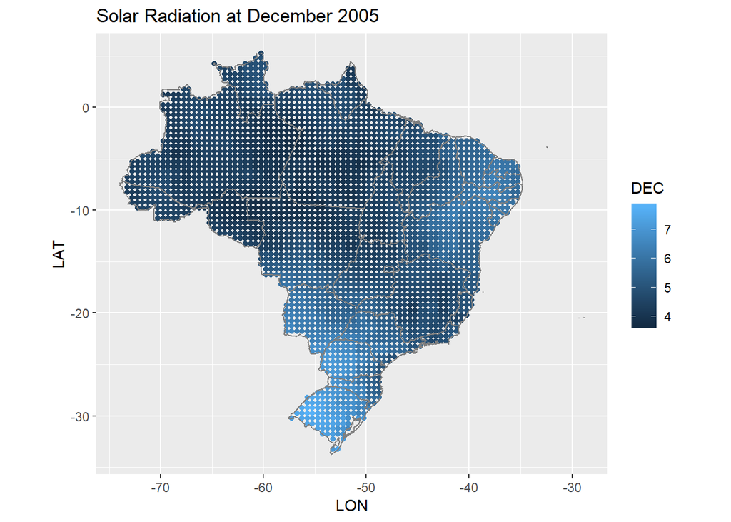

```r
df1 <- subset(df, YEAR == 2005)
df3 <- df1[complete.cases(df1), c("LON", "LAT", "DEC")]
ggplot(df3[complete.cases(df3),], aes(x=LON, y=LAT, color=DEC)) +
    ggtitle("Solar Radiation at December 2005") +
    geom_point()+
    geom_path(data=states,aes(x=long, y=lat,group=group), colour="grey50")+
    scale_fill_gradientn(colours=rev(brewer.pal(7,"Spectral")))+
    coord_fixed()
```

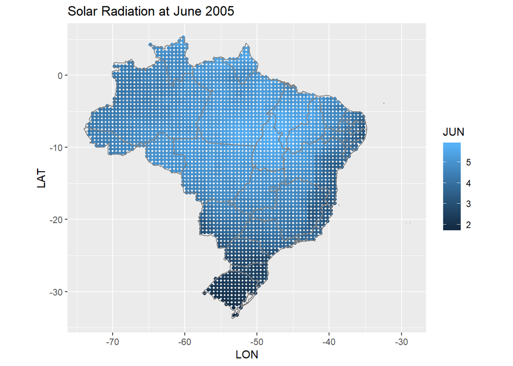

```r
df4 <- df1[complete.cases(df1), c("LON", "LAT", "JUN")]
ggplot(df4[complete.cases(df4),], aes(x=LON, y=LAT, color=JUN)) +
    ggtitle("Solar Radiation at June 2005") +
    geom_point()+
    geom_path(data=states,aes(x=long, y=lat,group=group), colour="grey50")+
    scale_fill_gradientn(colours=rev(brewer.pal(7,"Spectral")))+
    coord_fixed()
```